# 5160_HW-5

Mostafa

3/16/2021

## 1

### 1.a.

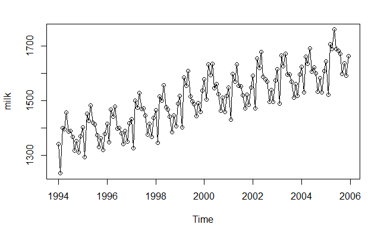

```r
library(TSA)
data(milk)
plot(milk, type = "o")
```

**Answer**:  
- Increasing trend: Yes  
- mean: increasing  
- variance: almost constant  
- Seasonality trend: Somehow  
- Stationary: No

### 1.b.

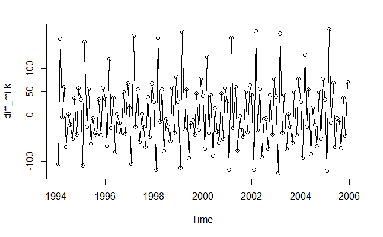

```r
diff_milk <- diff(milk)
plot(diff_milk, ylab="diff_milk", type = "o")
```

**Answer**:  
- Increasing trend: Not anymore  
- mean: almost zero  
- variance: almost constant  
- Seasonality trend: Somehow  
- Stationary: It seems still not

The increasing trend has been removed compared to the original data but still could be following a seasonal trend. when compared to the inital gragh the second looks more close to stationary.

### 1.c.

```r
fit1 <- lm(diff_milk~time(diff_milk))
fit1
```

```
Call:
lm(formula = diff_milk ~ time(diff_milk))

Coefficients:
    (Intercept)  time(diff_milk)
      21.443908        -0.009603
```

**Answer**:  
The slope `-0.009603` is very low. So, we can conclude that it is almost zero mean.

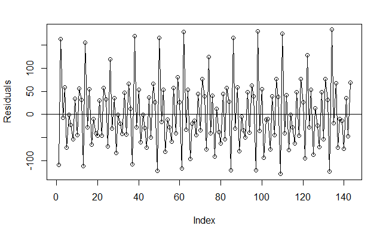

```r
plot(fit1$residuals, ylab = "Residuals", type = "o")
abline(h = 0)
```

**Answer**:  
The points are evenly distributed around the abline=0. So, we can conclude that the variance is constant. However, there are some spikes that might be because of seasonality trend.So, it is hard to say that the residuals are independent. Finally, I think the residuals are not independent.

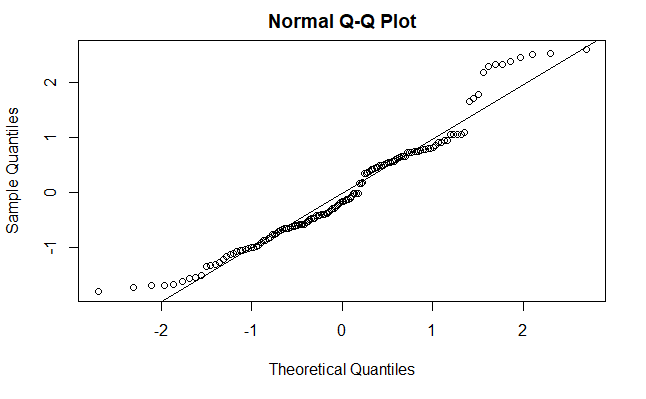

```r
qqnorm(rstudent(fit1))
qqline(rstudent(fit1))
```

**Answer**:  
Not only is not it normal, but also we can see some level of seasonality in it.

```r
shapiro.test(rstudent(fit1))
```

```
    Shapiro-Wilk normality test

data:  rstudent(fit1)
W = 0.95711, p-value = 0.0001978
```

**Answer**:  
From pvalue we conclude that the standardized residuals are not normally distributed.

```r
runs(rstudent(fit1))
```

```
$pvalue
[1] 5.14e-07

$observed.runs
[1] 100

$expected.runs
[1] 70.95804

$n1
[1] 82

$n2
[1] 61

$k
[1] 0
```

**Answer**:  
first differences data: not normal & not independent

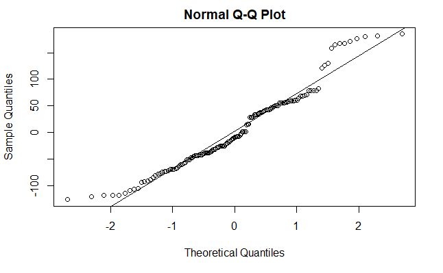

```r
qqnorm(diff(milk))
qqline(diff(milk))
```

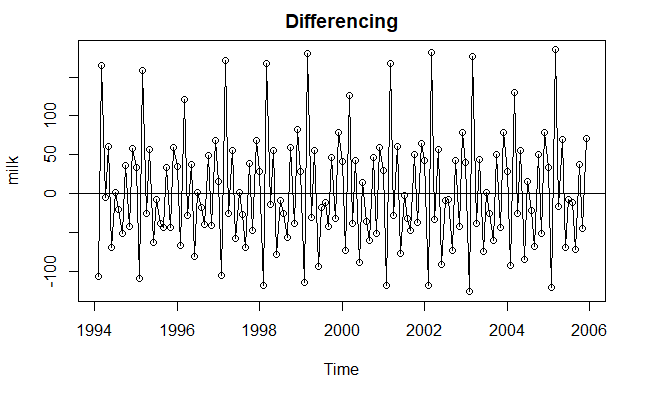

```r
plot(diff(milk),main="Differencing",type="o")
abline(h=0)
```

```r
# Runs test to check the independency
runs(diff(milk))
```

```
$pvalue
[1] 5.73e-10

$observed.runs
[1] 108

$expected.runs
[1] 71.90909

$n1
[1] 78

$n2
[1] 65

$k
[1] 0
```

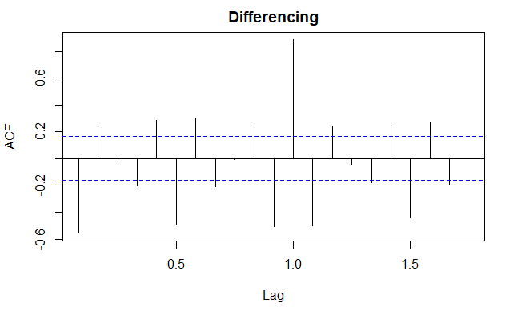

```r
acf(diff(milk),main="Differencing")
```

**Answer**:  
There are some spikes fall out of the margin errors cut off. So, these likely does not resemble a white noise process.

## 2

```r
set.seed(1)
AR1 <- arima.sim(list(order = c(1,0,0), ar = 0.4), n = 200)
Wt = exp(AR1)
```

### 2.a.

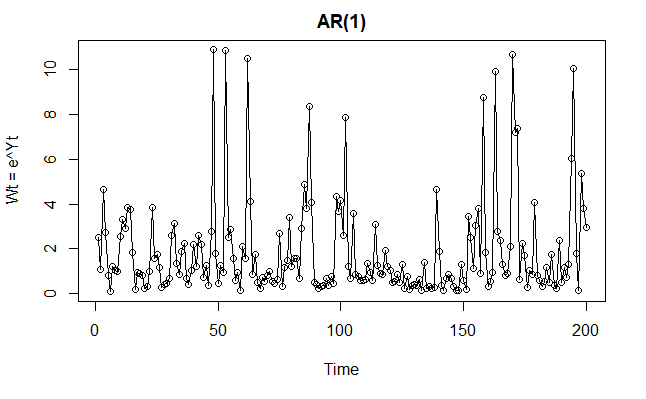

```r
# Plot of AR(1) process
plot(Wt, ylab = "Wt = e^Yt", main = 'AR(1)', type = 'o')
```

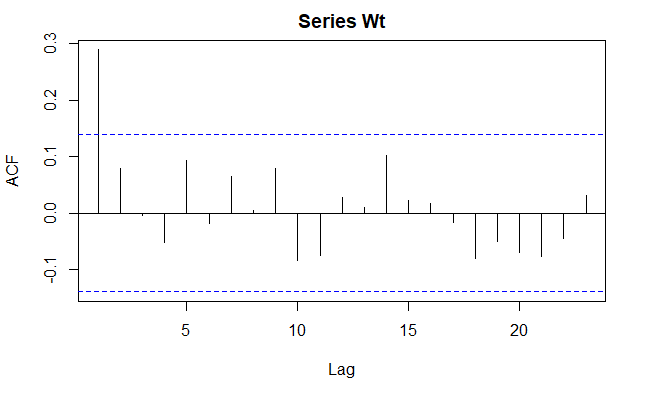

```r
acf(Wt)
```

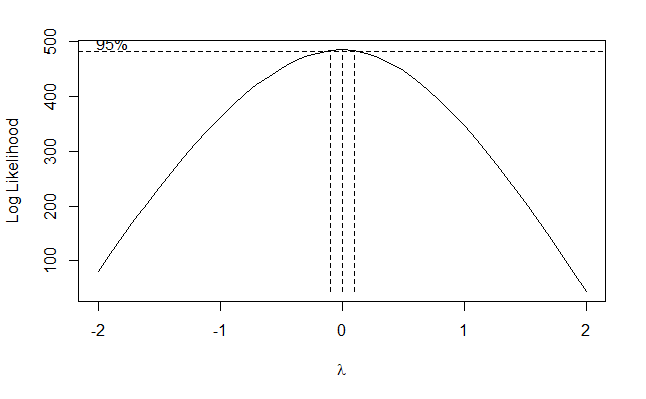

```r
BoxCox.ar(Wt)
```

**Answer**:  
As Lambda=0 ==> Log transformation

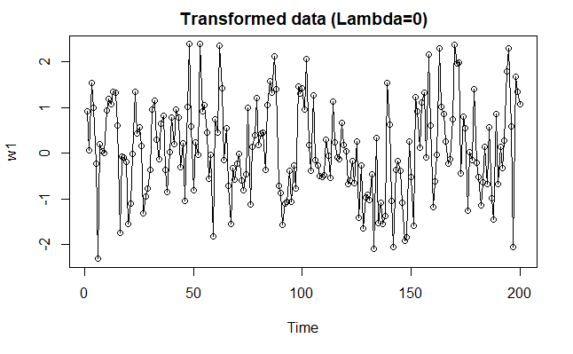

```r
w1 <- log(Wt)
plot(w1, main="Transformed data (Lambda=0)", type = "o")
```

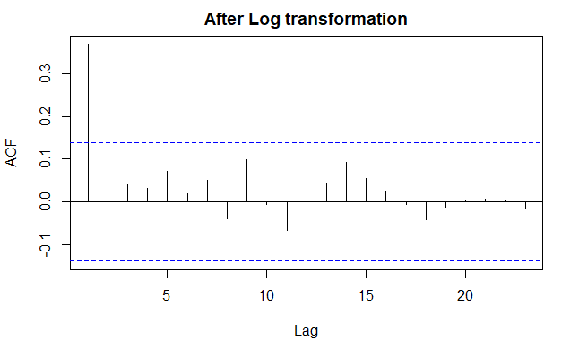

```r
acf(w1, main = 'After Log transformation')
```

**Answer**:  
It seems to be more stationary after the log transformation.